# EXPLORATORY DATA ANALYSIS ON PENQUIN DATASET

It is a dataset comprising various measurements of three different penguin species, namely Adelie, Gentoo, and Chinstrap. Same as Iris data which had measurements of three different species of the Iris flower. Anyway, both are great for what they are made of.

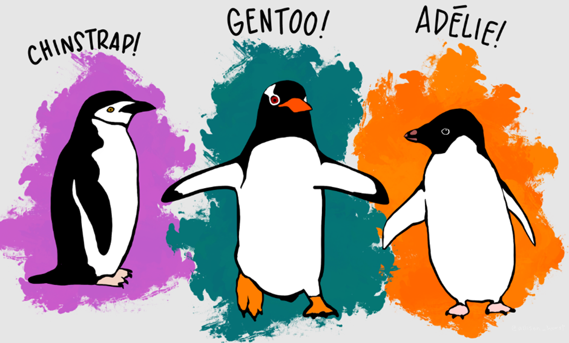

The rigorous study was conducted in the islands of the Palmer Archipelago, Antarctica. These data were collected from 2007 to 2009 by Dr. Kristen Gorman with the Palmer Station Long Term Ecological Research Program, part of the US Long Term Ecological Research Network.

The original GitHub repo contains the source code. You may download the dataset from Kaggle. It has two datasets, each with 344 observations. The dataset we will be using is a curated subset of the raw dataset.

# UNDERSTANDING DATASET:

**Of the 7 columns, 3 are categorical ( species , island , sex ) and the rest are numeric**

**island :** a factor denoting island in Palmer Archipelago, Antarctica (Biscoe, Dream or Torgersen)

**culmen_length_mm :** a number denoting bill length (millimeters)

**culmen_depth_mm :** a number denoting bill depth (millimeters)

**flipper_length_mm :** an integer denoting flipper length (millimeters)

**body_mass_g :** an integer denoting body mass (grams)

**sex :** a factor denoting penguin sex (female, male)

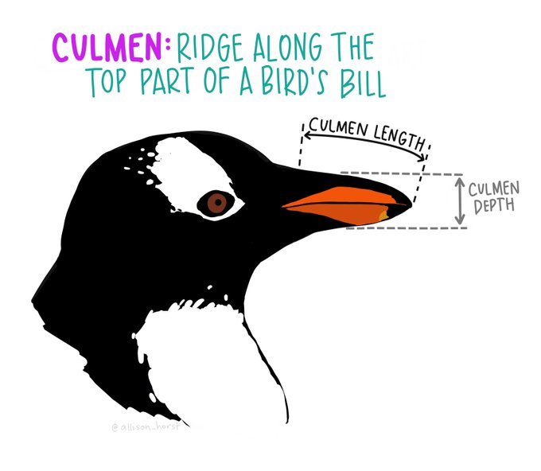

**Let's understand flipper length**

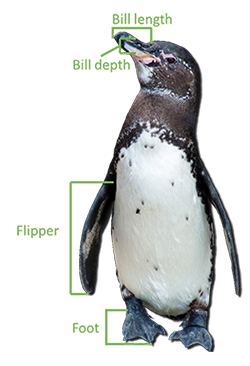

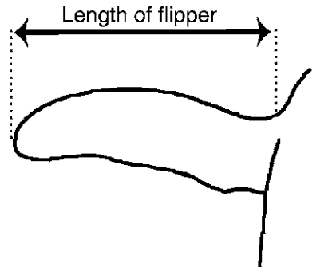

# EXPLORING DATA:

The first step is to import packages that are needed to explore the data from penquin dataset.

```python
import pandas as pd
import matplotlib.pyplot as plt
import seaborn as sns
```

# Next step is reading our dataset

```python
pdata=pd.read_csv('/kaggle/input/penquin-dataset/penguins_size.csv')
pdata
```

|  | species | island | culmen_length_mm | culmen_depth_mm | flipper_length_mm | body_mass_g | sex |
| --- | --- | --- | --- | --- | --- | --- | --- |
| 0 | Adelie | Torgersen | 39.1 | 18.7 | 181.0 | 3750.0 | MALE |
| 1 | Adelie | Torgersen | 39.5 | 17.4 | 186.0 | 3800.0 | FEMALE |
| 2 | Adelie | Torgersen | 40.3 | 18.0 | 195.0 | 3250.0 | FEMALE |
| 3 | Adelie | Torgersen | NaN | NaN | NaN | NaN | NaN |
| 4 | Adelie | Torgersen | 36.7 | 19.3 | 193.0 | 3450.0 | FEMALE |
| ... | ... | ... | ... | ... | ... | ... | ... |
| 339 | Gentoo | Biscoe | NaN | NaN | NaN | NaN | NaN |
| 340 | Gentoo | Biscoe | 46.8 | 14.3 | 215.0 | 4850.0 | FEMALE |
| 341 | Gentoo | Biscoe | 50.4 | 15.7 | 222.0 | 5750.0 | MALE |
| 342 | Gentoo | Biscoe | 45.2 | 14.8 | 212.0 | 5200.0 | FEMALE |
| 343 | Gentoo | Biscoe | 49.9 | 16.1 | 213.0 | 5400.0 | MALE |

344 rows × 7 columns

```python
pdata.info()
```

```
<class 'pandas.core.frame.DataFrame'>
RangeIndex: 344 entries, 0 to 343
Data columns (total 7 columns):
 #   Column             Non-Null Count  Dtype
---  ------             --------------  -----
 0   species            344 non-null    object
 1   island             344 non-null    object
 2   culmen_length_mm   342 non-null    float64
 3   culmen_depth_mm    342 non-null    float64
 4   flipper_length_mm  342 non-null    float64
 5   body_mass_g        342 non-null    float64
 6   sex                334 non-null    object
dtypes: float64(4), object(3)
memory usage: 18.9+ KB
```

# REMOVING NULL VALUES FROM DATASET

```python
df=pdata
df.dropna()
```

|  | species | island | culmen_length_mm | culmen_depth_mm | flipper_length_mm | body_mass_g | sex |
| --- | --- | --- | --- | --- | --- | --- | --- |
| 0 | Adelie | Torgersen | 39.1 | 18.7 | 181.0 | 3750.0 | MALE |
| 1 | Adelie | Torgersen | 39.5 | 17.4 | 186.0 | 3800.0 | FEMALE |
| 2 | Adelie | Torgersen | 40.3 | 18.0 | 195.0 | 3250.0 | FEMALE |
| 4 | Adelie | Torgersen | 36.7 | 19.3 | 193.0 | 3450.0 | FEMALE |
| 5 | Adelie | Torgersen | 39.3 | 20.6 | 190.0 | 3650.0 | MALE |
| ... | ... | ... | ... | ... | ... | ... | ... |
| 338 | Gentoo | Biscoe | 47.2 | 13.7 | 214.0 | 4925.0 | FEMALE |
| 340 | Gentoo | Biscoe | 46.8 | 14.3 | 215.0 | 4850.0 | FEMALE |
| 341 | Gentoo | Biscoe | 50.4 | 15.7 | 222.0 | 5750.0 | MALE |
| 342 | Gentoo | Biscoe | 45.2 | 14.8 | 212.0 | 5200.0 | FEMALE |
| 343 | Gentoo | Biscoe | 49.9 | 16.1 | 213.0 | 5400.0 | MALE |

334 rows × 7 columns

```python
df=df.dropna()
df.shape
```

```
(334, 7)
```

# HOW MANY SPECIES ARE THERE?

```python
pdata.species.value_counts() #### NUMBER OF SPECIES
```

```
Adelie       152
Gentoo       124
Chinstrap     68
Name: species, dtype: int64
```

```python
df.species.value_counts() ##### AFTER REMOVING NAN VALUES
```

```
Adelie       146
Gentoo       120
Chinstrap     68
Name: species, dtype: int64
```

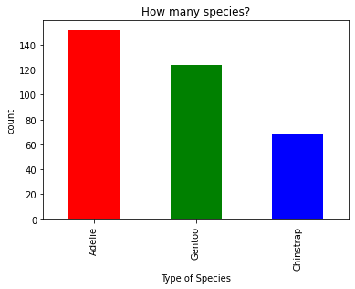

```python
pdata.species.value_counts().plot(kind='bar',color=['r','g','b'],title="How many species?",xlabel='Type of Species',ylabel='count')
```

# HOW MANY ISLANDS ARE THERE?

```python
pdata.island.value_counts()
```

```
Biscoe       168
Dream        124
Torgersen     52
Name: island, dtype: int64
```

[figure not shown]

```python
pdata.island.value_counts().plot(kind='bar',color=['blue','green','black'],figsize=[10,6],xlabel='Type of Species',ylabel='count')
```

# HOW MANY PENQUINS ARE THERE IN EACH GENDER?

```python
pdata.sex.value_counts()
```

```
MALE      169
FEMALE    165
Name: sex, dtype: int64
```

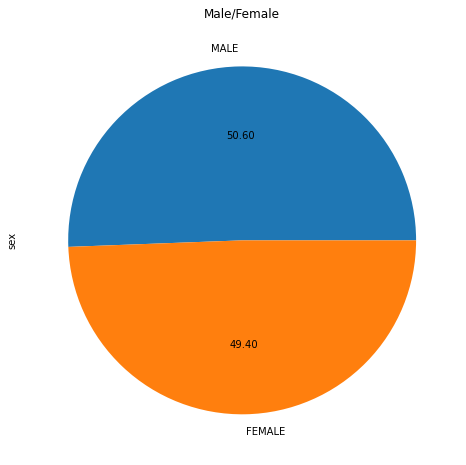

```python
pdata.sex.value_counts().plot(kind='pie',autopct='%.2f',figsize=[8,8],title='Male/Female')
```

# RELATION (CULMEN LENGTH / BODY MASS)

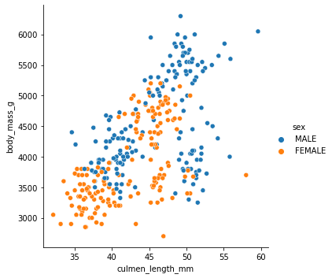

```python
sns.relplot(data=pdata,x='culmen_length_mm',y='body_mass_g',hue='sex')#### BASED ON GENDER
```

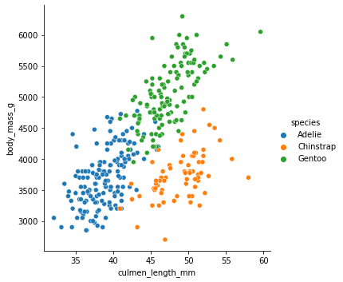

```python
sns.relplot(data=pdata,x='culmen_length_mm',y='body_mass_g',hue='species')#### BASED ON SPECIES
```

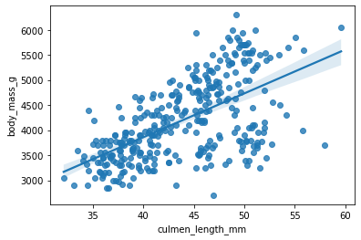

```python
sns.regplot(data=pdata,x='culmen_length_mm',y='body_mass_g')
```

# RELATION (FLIPPER LENGTH / BODY MASS)

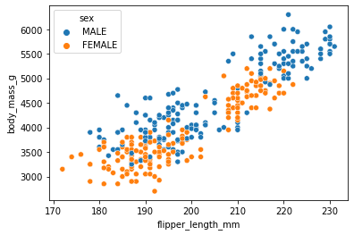

```python
sns.scatterplot(data=pdata,x='flipper_length_mm',y='body_mass_g',hue='sex') #### BASED ON GENDER
```

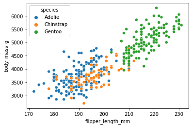

```python
sns.scatterplot(data=pdata,x='flipper_length_mm',y='body_mass_g',hue='species')#### BASED ON SPECIES
```

# RELATION (CULMEN DEPTH / BODY MASS)

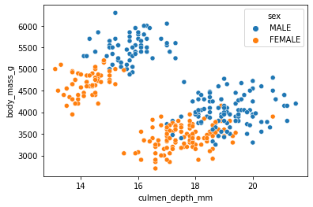

```python
sns.scatterplot(data=pdata,x='culmen_depth_mm',y='body_mass_g',hue='sex') #### BASED ON GENDER
```

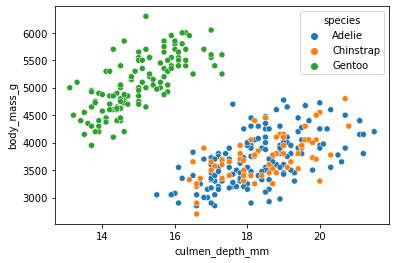

```python
sns.scatterplot(data=pdata,x='culmen_depth_mm',y='body_mass_g',hue='species') #### BASED ON SPECIES
```

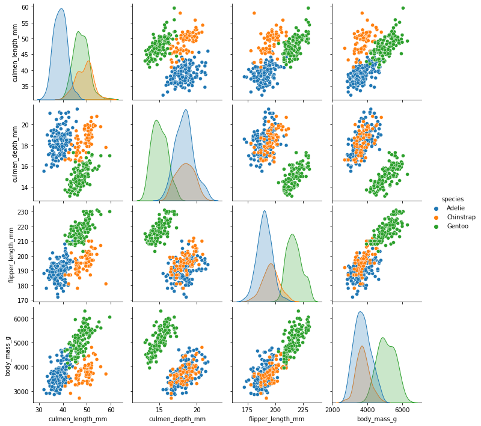

```python
sns.pairplot(data=df,hue='species')
```

# AVERAGE CULMEN LENGTH,DEPTH OF EACH SPECIES

```python
grps=df.groupby('species')
```

```python
grps.mean()
```

| species | culmen_length_mm | culmen_depth_mm | flipper_length_mm | body_mass_g |
| --- | --- | --- | --- | --- |
| Adelie | 38.823973 | 18.347260 | 190.102740 | 3706.164384 |
| Chinstrap | 48.833824 | 18.420588 | 195.823529 | 3733.088235 |
| Gentoo | 47.542500 | 15.002500 | 217.233333 | 5090.625000 |

```python
df.describe()
```

|  | culmen_length_mm | culmen_depth_mm | flipper_length_mm | body_mass_g |
| --- | --- | --- | --- | --- |
| count | 334.000000 | 334.000000 | 334.000000 | 334.000000 |
| mean | 43.994311 | 17.160479 | 201.014970 | 4209.056886 |
| std | 5.460521 | 1.967909 | 14.022175 | 804.836129 |
| min | 32.100000 | 13.100000 | 172.000000 | 2700.000000 |
| 25% | 39.500000 | 15.600000 | 190.000000 | 3550.000000 |
| 50% | 44.500000 | 17.300000 | 197.000000 | 4050.000000 |
| 75% | 48.575000 | 18.700000 | 213.000000 | 4793.750000 |
| max | 59.600000 | 21.500000 | 231.000000 | 6300.000000 |

```python
grps.std()
```

| species | culmen_length_mm | culmen_depth_mm | flipper_length_mm | body_mass_g |
| --- | --- | --- | --- | --- |
| Adelie | 2.662597 | 1.219338 | 6.521825 | 458.620135 |
| Chinstrap | 3.339256 | 1.135395 | 7.131894 | 384.335081 |
| Gentoo | 3.105692 | 0.983944 | 6.557738 | 499.759002 |

```python
grps.cov()
```

| species |  | culmen_length_mm | culmen_depth_mm | flipper_length_mm | body_mass_g |
| --- | --- | --- | --- | --- | --- |
| Adelie | culmen_length_mm | 7.089421 | 1.252583 | 5.769934 | 664.627067 |
|  | culmen_depth_mm | 1.252583 | 1.486786 | 2.472352 | 324.430798 |
|  | flipper_length_mm | 5.769934 | 2.472352 | 42.534199 | 1390.396788 |
|  | body_mass_g | 664.627067 | 324.430798 | 1390.396788 | 210332.427964 |
| Chinstrap | culmen_length_mm | 11.150630 | 2.477801 | 11.231431 | 659.199956 |
|  | culmen_depth_mm | 2.477801 | 1.289122 | 4.697717 | 263.786216 |
|  | flipper_length_mm | 11.231431 | 4.697717 | 50.863916 | 1758.538191 |
|  | body_mass_g | 659.199956 | 263.786216 | 1758.538191 | 147713.454785 |
| Gentoo | culmen_length_mm | 9.645321 | 1.968212 | 13.478235 | 1035.359769 |
|  | culmen_depth_mm | 1.968212 | 0.968145 | 4.574202 | 353.195903 |
|  | flipper_length_mm | 13.478235 | 4.574202 | 43.003922 | 2329.726891 |
|  | body_mass_g | 1035.359769 | 353.195903 | 2329.726891 | 249759.059874 |

```python
grps.corr()
```

| species |  | culmen_length_mm | culmen_depth_mm | flipper_length_mm | body_mass_g |
| --- | --- | --- | --- | --- | --- |
| Adelie | culmen_length_mm | 1.000000 | 0.385813 | 0.332274 | 0.544276 |
|  | culmen_depth_mm | 0.385813 | 1.000000 | 0.310897 | 0.580156 |
|  | flipper_length_mm | 0.332274 | 0.310897 | 1.000000 | 0.464854 |
|  | body_mass_g | 0.544276 | 0.580156 | 0.464854 | 1.000000 |
| Chinstrap | culmen_length_mm | 1.000000 | 0.653536 | 0.471607 | 0.513638 |
|  | culmen_depth_mm | 0.653536 | 1.000000 | 0.580143 | 0.604498 |
|  | flipper_length_mm | 0.471607 | 0.580143 | 1.000000 | 0.641559 |
|  | body_mass_g | 0.513638 | 0.604498 | 0.641559 | 1.000000 |
| Gentoo | culmen_length_mm | 1.000000 | 0.644085 | 0.661791 | 0.667071 |
|  | culmen_depth_mm | 0.644085 | 1.000000 | 0.708910 | 0.718265 |
|  | flipper_length_mm | 0.661791 | 0.708910 | 1.000000 | 0.710870 |
|  | body_mass_g | 0.667071 | 0.718265 | 0.710870 | 1.000000 |

# CONCLUSION

So ,this is all about exploratory data analysis done on penquin dataset.Here are some takeaways from this.

- Understanding the dataset and figuring out categorical and numerical values
- How the barchart,piechart,scatterplot,regression plot,pair plot,relation plot is applied on numerical values to get realtively good insights about the data
- Finally finding out the mean,standard deviation,covariance and correlation on numerical values in dataset